# Quantitative Genomics and Genetics 2017

## Computer Lab 7

– 13 April 2017

– Author: Afrah Shafquat

### 1. Principal Component Analysis

One of the biggest challenges in dealing with gene expression or genotype data is the high dimensionality of the data. Transcriptome wide gene expression datasets usally have 10,000 + gene expression levels measured and commonly used genotype datasets have around 600,000 ~ 900,0000 dimensions. The high dimensionalities not only make it difficult to perform statistical analyses on the data, but also make it hard to visualize and inspect the data. Today we will learn how to use Principal component analysis (PCA) to deal with this problem.

I also highly recommend the tutorial written by Jonathon Shlens: http://arxiv.org/pdf/1404.1100.pdf

#### PCA in R

Let’s begin with a simple case where we have two measured variables x and y which are generated like this:

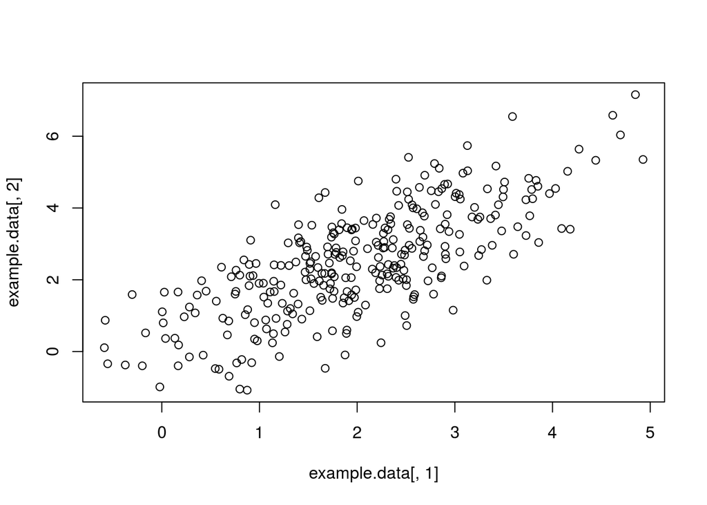

```r
x <- 2 + rnorm(300,0,1)
y <- 0.5 + 1*x + rnorm(300,0,1)

example.data <- cbind(x,y)
plot(example.data[,1],example.data[,2])
```

We can see that x and y are heavily correlated, which is not very surprising since the value of y was generated based on the value of x. In this case we don’t really need to reduce the dimensions since a 2-D plot is easy to generate. However, for the sake of demonstration (and the lack of ability to plot 4 or 5 dimensional data) let us try to reduce this 2 dimensional dataset into a single dimension without losing too much information. The most valuable information in this dataset is probably the correlation between x and y (since there is not much left if you take that relationship out… just normal errors). So it seems like a good idea to keep that information in the single dimension that we have. Let’s first center our data to (0,0) to make it easier to draw vectors.

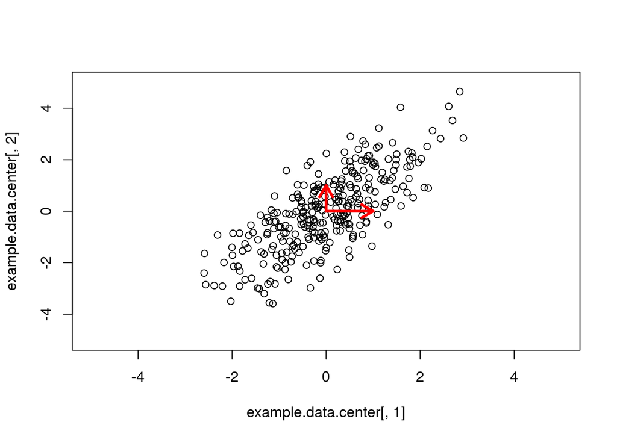

```r
example.data.center <- scale(example.data, center = TRUE, scale = FALSE)
plot(example.data.center[,1], example.data.center[,2],xlim = c(-5,5), ylim = c(-5,5))
arrows(x0=0, y0=0, x1 = 1, y1 = 0, col = "red", lwd = 3,length =0.15)
arrows(x0=0, y0=0, x1 = 0, y1 = 1, col = "red", lwd = 3,length =0.15)
```

So right now the data is represented by the coordinates of x and y, and the basis vectors are (1,0) and (0,1) shown as the red arrows. In order to capture the relationship between x and y and representing the data in 1-D we would probably use a vector that goes along the diagonal of the data. The direction along the diagonal explains the the largest amount of variance in the data (has the largest spread along its direction) and if we project each data point onto this vector we wont be losing too much information about the relationship between x and y. Let’s find out the exact direction of that vector by using pca in R. There are two functions in R that are commonly used to perform pca: prcomp() and princomp(). Although they are doing the same thing, they use slightly different methods to calculate the outcomes and prcomp() happens to use the method that is faster and is computationally less expensive. So let’s use prcomp() to do our calculations.

```r
# when you use prcomp, your input data should have measrued variables in columns and individual samples/points as rows (N samples x G genes (genotypes))
pca.result <- prcomp(example.data.center)
```

That was easy, but what is saved in the result?

```r
str(pca.result)
```

```
List of 5
 $ sdev    : num [1:2] 1.735 0.621
 $ rotation: num [1:2, 1:2] 0.533 0.846 0.846 -0.533
  ..- attr(*, "dimnames")=List of 2
  .. ..$ : chr [1:2] "x" "y"
  .. ..$ : chr [1:2] "PC1" "PC2"
 $ center  : Named num [1:2] 1.30e-16 1.37e-16
  ..- attr(*, "names")= chr [1:2] "x" "y"
 $ scale   : logi FALSE
 $ x       : num [1:300, 1:2] -1.0529 0.6109 5.4463 0.0081 -1.791 ...
  ..- attr(*, "dimnames")=List of 2
  .. ..$ : NULL
  .. ..$ : chr [1:2] "PC1" "PC2"
 - attr(*, "class")= chr "prcomp"
```

You can see that there are 5 different results saved in the variable pca.result.

```r
#$sdev contains information about the fraction of variation explained by a certain principal component.
pca.result$sdev
```

```
[1] 1.7352009 0.6208679
```

```r
pcs = (pca.result$sdev / sum(pca.result$sdev))*100

print(pcs)
```

```
[1] 73.64814 26.35186
```

```r
#$rotation contains the directions of principal components in each of its columns.
pca.result$rotation
```

```
        PC1        PC2
x 0.5332846  0.8459359
y 0.8459359 -0.5332846
```

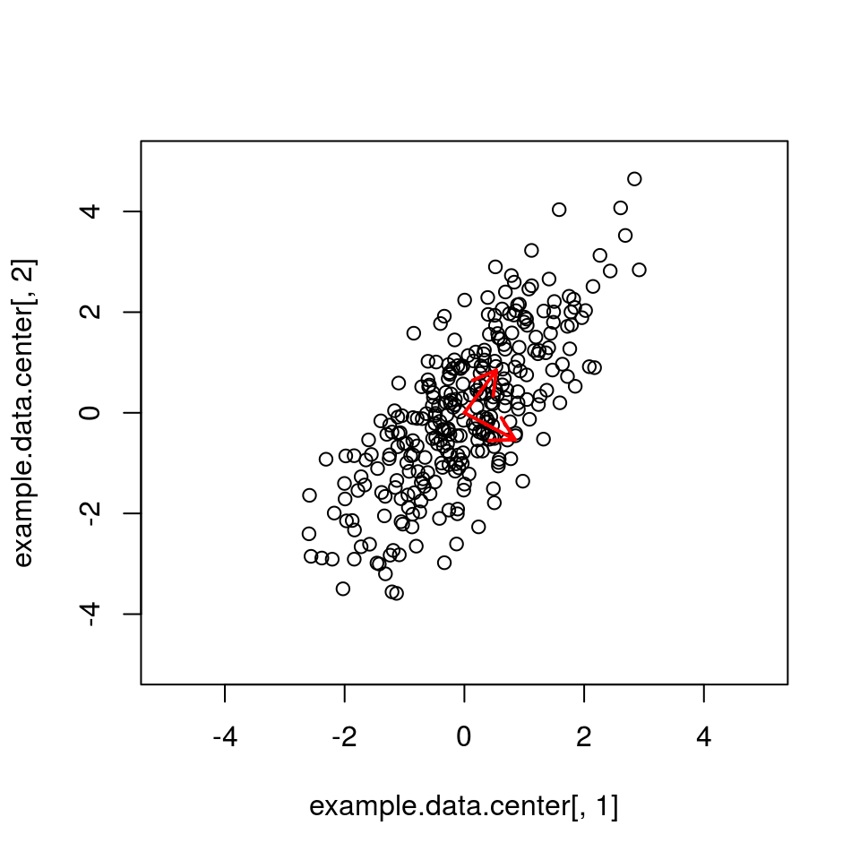

```r
plot(example.data.center[,1], example.data.center[,2],xlim = c(-5,5), ylim = c(-5,5))
arrows(x0=0, y0=0, x1 = pca.result$rotation[1,1], y1 = pca.result$rotation[2,1], col = "red", lwd = 2,length =0.15)
arrows(x0=0, y0=0, x1 = pca.result$rotation[1,2], y1 = pca.result$rotation[2,2], col = "red", lwd = 2,length =0.15)
```

- We can see that the first PC is the direction along the diagonal.

```r
#$center contains the mean for each data column (in our case it would be close or equal to 0 since we centered the data).
pca.result$center
```

```
           x            y
1.302662e-16 1.369275e-16
```

```r
#$scale contains information about whether or not we gave the option to scale (divide it by its standard deviation) the data.
pca.result$scale
```

```
[1] FALSE
```

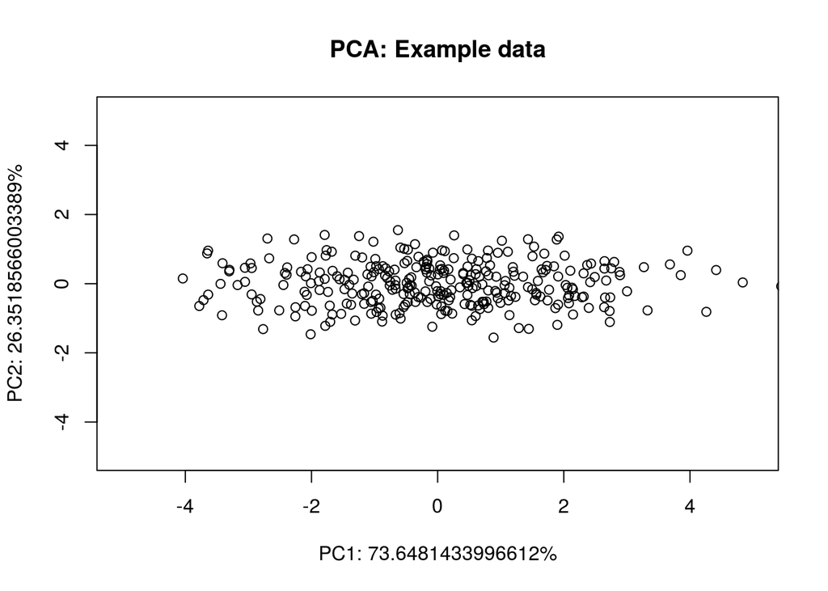

```r
#$x contains the coordinate values of the data projected to a principal component in each of its columns.
plot(pca.result$x[,1],pca.result$x[,2],xlim = c(-5,5), ylim = c(-5,5), xlab=paste0('PC1: ', pcs[1],'%'), ylab=paste0('PC2: ',pcs[2],'%'), main='PCA: Example data')
```

You can see that the representation of the data looks like a rotation using the diagonal of the original data as the first axis. So if we are interested in only keeping 1-D of the data without losing too much information, our best shot would be to keep the first column of the projected data pca.result$x[,1].